# Etwas R am Abend

# Häufigkeitstabelle und Balkendiagramme

Und mit dem Befehl **barplot()** erstellen wir ein Balkendiagramm daraus:

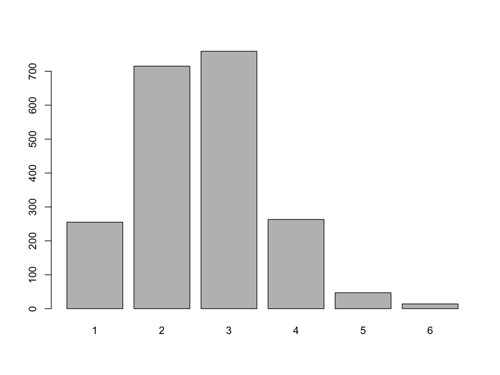

```r
barplot( table(miete03$rooms) )
```

# Schönere Diagramme mit **ggplot2**

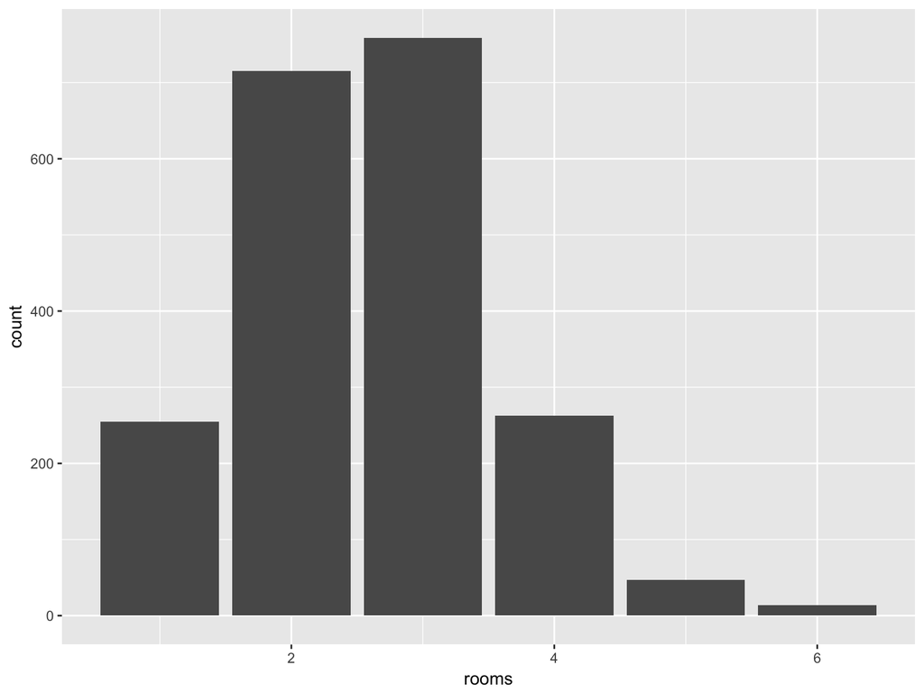

```r
library(ggplot2) # Bibliothek laden!
ggplot(miete03, aes( x = rooms)) + geom_bar()
```

# Mehr Informationen zu **ggplot2**

Wie man mit **ggplot2** noch mehr und noch schönere Grafiken erstellt, können Sie finden bei:

- http://ggplot2.org
- http://docs.ggplot2.org/current/index.html
- http://www.cookbook-r.com/Graphs/
- https://www.datacamp.com/courses/data-visualization-with-ggplot2-1
- http://r4ds.had.co.nz

# Mehr Informationen zu **R**

Hier finden Sie Videos, die einige Schritte der Datenaufbereitung und deskriptiver/ explorativer Datenanalyse erläutern (zumeist mit R-Commander):

- boxplots erstellen https://www.youtube.com/watch?v=9XBjOmA7sNs
- Textdatei öffnen https://www.youtube.com/watch?v=QnM9HBe23Y8
- Öffnen der Datei Polizeistudie https://www.youtube.com/watch?v=SDOoKuj5_7o
- SPSS Datei importieren https://www.youtube.com/watch?v=HS8H_n7Vrm0
- Deskriptive Statistik erstellen https://www.youtube.com/watch?v=qrMpgk-7Wus
- Variablen in Faktoren umwandeln und Balkendiagramm https://www.youtube.com/watch?v=PRR-3kblt8k
- Streudiagramm https://www.youtube.com/watch?v=brE72_0stO0
- Korrelationsmatrix https://www.youtube.com/watch?v=pl92q_S-r8E
- Datenmatrix erstellen https://youtu.be/-EaeBL9J4IE

Die Videos wurden von Frau Prof. Ferreira erstellt.